# 2.2.3 日常运动量随机森林预测模型开发与测试

### 试题名称

日常运动量随机森林预测模型开发与测试

### 场地设备要求

（1）人工智能训练师主机 1 台；

（2）Python 编译环境；

（3）fitness analysis数据集。

### 考核时间

20min

### 工作任务

随着人们健康意识的增强，越来越多的人开始关注日常运动和健康管理。使用提供的训练数据，补全2.2.3.ipynb代码。选择合适的特征，开发一个预测模型，基于个体性别，个体对运动的看法和个人健康评价来预测个体年龄。利用测试工具对模型进行测试，并对测试结果进行分析，完成测试报告，并运用工具对错误原因进行纠正。

详细说明如下：

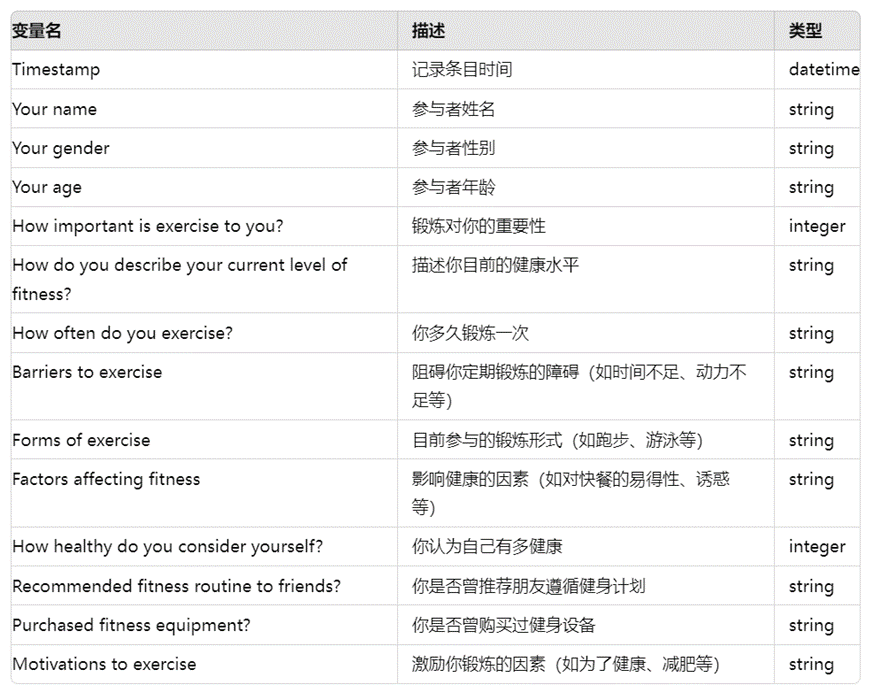

（1）正确加载数据集，并显示前五行的数据

（2）使用随机森林模型进行模型训练，要求设定自变量和因变量，并根据自变量特征进行模型训练，最终将训练好的模型以文件名2.2.3_model.pkl保存到考生文件夹，结果文件以2.2.3_results.txt保存到考生文件夹。

（3）使用测试工具对模型进行测试，并记录测试结果，命名2.2.3_report.txt，保存到考生文件夹

（4）对测试结果进行详细分析，并编写测试报告，包括模型性能评估、错误分析及改进建议，将答案写到答题卷文件中，答题卷文件命名为“2.2.3.xlsx”，保存到考生文件夹。

（5）运用工具分析算法中错误案例产生的原因并进行纠正，重新得到模型训练结果，以文件名2.2.3_results_xgb.txt保存到考生文件夹。

（6）将以上代码以及运行结果，以html格式保存并命名为2.2.3.html，保存到考生文件夹，考生文件夹命名为“准考证号+身份证后6位”。

### 技能要求

(1) 能够维护日常训练集与测试集。

(2) 能使用工具对算法进行训练。

(3) 能够使用测试工具对人工智能产品的使用进行测试。

(4) 能够对测试结果进行分析，编写测试报告。

(5) 能够运用工具，分析算法中错误案例产生的原因并进行纠正。

### 质量指标

(1) 深入理解业务，训练符合业务需求的模型。

(2) 数据预处理步骤完整，方法选择合理。

(3) 代码实现正确，结果符合预期。

(4) 测试结果分析全面，报告详细

### 注意事项

考生文件夹可以保存在桌面。

jupyter notebook 工作目录：虚拟机环境中的D:\jupyter_notebook。

jupyter notebook 打开方式：在终端中输入jupyter notebook启动。

ipynb填充代码运行后，保存为html格式上传。保存方法：File->Download as->HTML(.html)。

ipynb代码在下划线上填充，请勿随意添加、删除或修改源代码的其他部分，以免影响考试结果。

### 答案上传

[output not shown]